# Stability + Quintiles

Sy Doan

February 16, 2017

# Decomposition of the teacher effect

In McCaffrey, et al. (2009), the authors decompose each year-specific teacher effect $\delta_{kt}$ as:

$$\delta_{kt} = \theta_k + \xi_{kt} + \varepsilon_{kt}$$

with each random component being distributed as $\theta_k \sim (0, \tau^2)$, $\xi_{kt} \sim (0, \nu^2)$, and $\varepsilon_{kt} \sim (0, se^2_{kt})$

Therefore, the stability coefficient, the proportion of total variation of the teacher-year effect $var(\delta_{kt})$ attributed to the persistent componet $\theta_k$, is described as:

$$\frac{\tau^2}{\tau^2 + \nu^2 + se^2_{kt}}$$

# Simulation

The question: for various values of the stability coefficient, what is the quintile placement of teacher effects in year 2 of teachers with year 1 effects in the first quintile?

Per Brendan’s suggestion, this simulation can be simplified by collapsing all non-persistent components of the teacher effect into one term, $\gamma_{kt} \sim (0, \pi^2)$:

$$\delta_{kt} = \theta_k + \gamma_{kt}$$

Therefore, the stability coefficient is now rewritten as:

$$\frac{\tau^2}{\tau^2 + \pi^2}$$

I want to simulate teacher effects for 10,000 people for 2 years. Therefore, I’ll want to draw 1 set of $\theta_k$ terms and 2 sets of $\gamma_{kt}$, $\gamma_{k1}$ and $\gamma_{k2}$, one for each year. All of these random terms are uncorrelated with one another. Therefore, the teacher effect for year 1 is simply $\theta_k + \gamma_{k1}$ and so on.

The means for all components are 0 and I want two things to be true about the variance:

1. The total variance of the teacher effects $var(\delta_{kt})$, to 1
2. The stability coefficient is equal to .3 (for this first example)

Because I’ve simplified down to two terms, this means that, for a given stability coefficient, $\tau^2 = stability$ and $\pi^2 = 1-stability$. Because $\theta_k$ and $\gamma_{kt}$ are independent (i.e., we don’t have to worry about covariance), $\theta_k + \gamma_{kt}$ will produce $\delta_{kt}$ with variance = 1.

```r
library(tidyverse)

stability <- .3

# draw theta terms
df <- rnorm(10000, mean = 0, sd = sqrt(stability)) %>% as.data.frame()
colnames(df) <- c('theta')

# draw gamma terms
df$gamma1 <- rnorm(10000, mean = 0, sd = sqrt(1-stability))
df$gamma2 <- rnorm(10000, mean = 0, sd = sqrt(1-stability))

# make teacher effects
# year 1
df$delta1 <- df$theta+df$gamma1
mean(df$delta1)
```

```
## [1] 0.00255679
```

```r
var(df$delta1)
```

```
## [1] 0.968853
```

```r
# year 2
df$delta2 <- df$theta+df$gamma2
mean(df$delta2)
```

```
## [1] -0.00254783
```

```r
var(df$delta2)
```

```
## [1] 1.01264
```

We then split up these teacher effects into quintiles:

```r
# Store Quintile Values
qval1 <- quantile(df$delta1, prob = seq(0,1,.2))
qval2 <- quantile(df$delta2, prob = seq(0,1,.2))

# Assign quintile groups to existing teacher effects
df$quintile1 <- ntile(df$delta1,5)
df$quintile2 <- ntile(df$delta2,5)
```

Now, we simply tabulate to see the year 2 quintile placement among teachers in quintile 1 in year 1

```r
# Obtain only quintile 1 teachers
q1teach <- filter(df, quintile1 == 1)
# Assign quintile groups to existing teacher effects
table(q1teach$quintile2) %>% prop.table(.)
```

```
##
##      1      2      3      4      5
## 0.3090 0.2660 0.1905 0.1425 0.0920
```

The numbers above match the numbers reported by McCaffrey, et al.

Visually, this is the distribution of year 1 effects, shading the portion of the distribution belonging to teachers who had quintile 1 effects in year 1

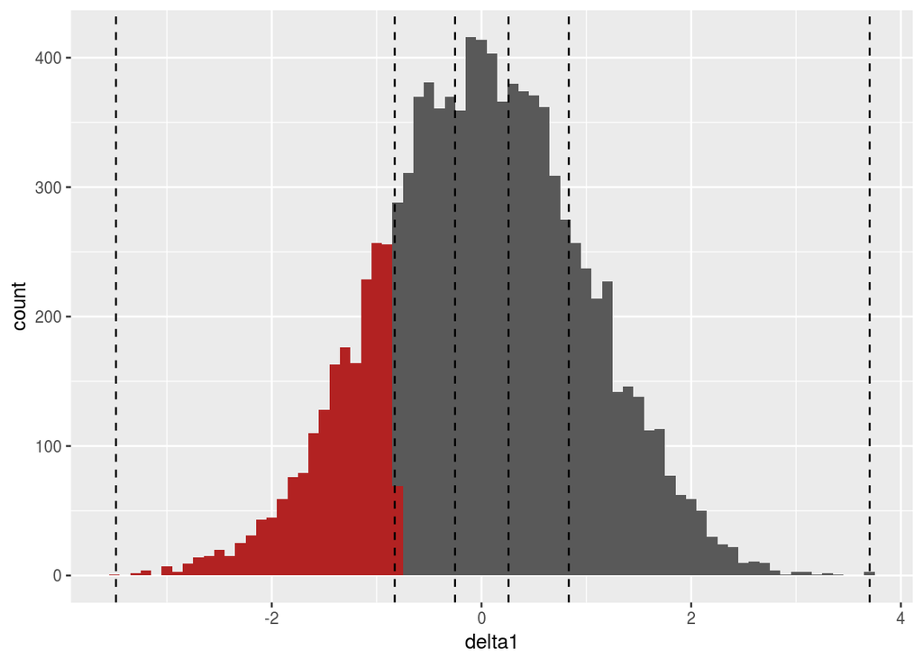

```r
ggplot(data = df, aes(x = delta1))+
  geom_histogram(binwidth = .1)+
  geom_histogram(data = q1teach, fill = 'firebrick', binwidth = .1)+
  geom_vline(xintercept = qval1, linetype = 'dashed')
```

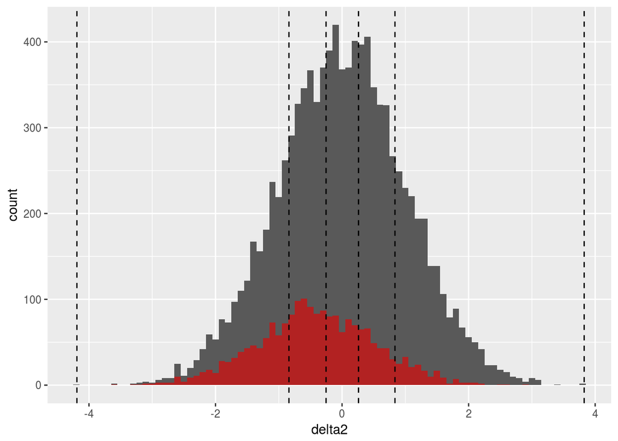

```r
ggplot(data = df, aes(x = delta2))+
  geom_histogram(binwidth = .1)+
  geom_histogram(data = q1teach, fill = 'firebrick', binwidth = .1)+
  geom_vline(xintercept = qval2, linetype = 'dashed')
```

If we run the same simulation but using a stability coefficient of .7, we get the following proportions and distributions:

```r
# Obtain only quintile 1 teachers
q1teach <- filter(df, quintile1 == 1)
# Assign quintile groups to existing teacher effects
table(q1teach$quintile2) %>% prop.table(.)
```

```
##
##      1      2      3      4      5
## 0.5660 0.2650 0.1180 0.0455 0.0055
```

Again, these numbers are very close to what is reported by McCaffrey et al. for a stability coefficient of .7.

Skipping the “year 1 quintile 1 over year 1 distribution” since you already know what that looks like …

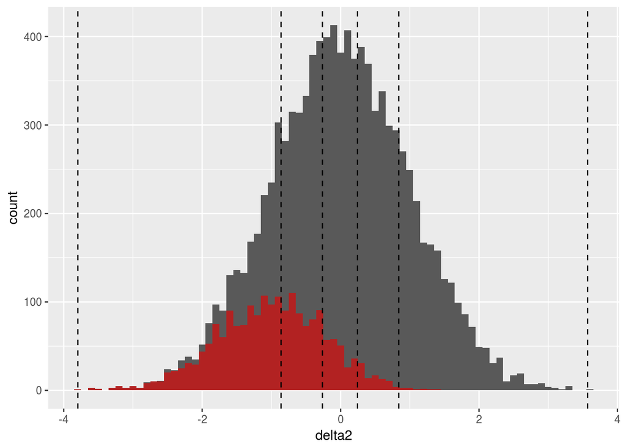

```r
ggplot(data = df, aes(x = delta2))+
  geom_histogram(binwidth = .1)+
  geom_histogram(data = q1teach, fill = 'firebrick', binwidth = .1)+
  geom_vline(xintercept = qval2, linetype = 'dashed')
```

As we might expect, because the stability coefficient is higher, more of the Quintile 1 in Year 1 teachers remain in Quintile 1 in Year 2.